# Technical Model Overview — Pre-Production Defect Risk Scorer

C01 Quality & Scrap · Model version 4 (Xgboost) · Generated June 24, 2026

Section 1

## Model Card

Model Name

defect_risk_scorer

Model Type

Xgboost (via scikit-learn Pipeline)

Version

4 — Production

Registry

MLflow Model Registry

Target Variable

defect_flag (quantity_failed > 0)

Prediction Type

Binary classification — defect probability [0, 1]

Operating Thresholds

High ≥ 0.75 · Medium ≥ 0.65

Hyperparameter Tuning

Optuna (150 trials, validation ROC-AUC objective)

Purpose

Embedded in ERP; scores each production work order for defect risk before job release, enabling pre-production intervention. Not intended for post-production diagnosis or scrap cost prediction.

Section 2

## Training Data

The model was trained on production work order data from a sheet metal fabrication operation covering January 2023 through December 2025. A time-based split was used to mirror the real deployment scenario where the model scores future jobs it has never seen.

| Split | Period | Work Orders | Defect Flag Rate |
| --- | --- | --- | --- |
| **Train** | Jan 2023 – Dec 2024 | 5,701 | 50.1% |
| **Validation** | Jan 2025 – Jun 2025 | 1,410 | 50.1% |
| **Test** | Jul 2025 – Dec 2025 | 2,173 | 50.2% |

Section 2.1

## Feature Set

Features are engineered in `src/features.py` and applied identically at training and scoring time. Interaction features encode domain-informed cross-system patterns identified in the diagnostic analysis.

| Feature | Type | Corr. with Target |
| --- | --- | --- |
| machine_type | Categorical | — |
| machine_id | Categorical | — |
| shift_code | Categorical | — |
| operator_id | Categorical | — |
| complexity | Categorical | — |
| material_type | Categorical | — |
| supplier | Categorical | — |
| lot_cert_status | Categorical | — |
| requires_welding | Categorical | 0.009 |
| machine_age_years | Numerical | 0.031 |
| std_labor_hrs | Numerical | 0.022 |
| quantity_ordered | Numerical | 0.272 |
| schedule_variance_hrs | Numerical | 0.002 |
| is_bending_shift_b | Interaction | 0.110 |
| is_high_complexity | Interaction | 0.172 |
| is_supplier_c_thin_gauge | Interaction | 0.148 |
| is_lapsed_cert_op | Interaction | 0.251 |

Section 2.2

## Class Balance by Split

Class balance is consistent across all three splits, confirming the time-based split did not introduce distributional shift in the target variable.

Defective vs Clean Work Orders by Split

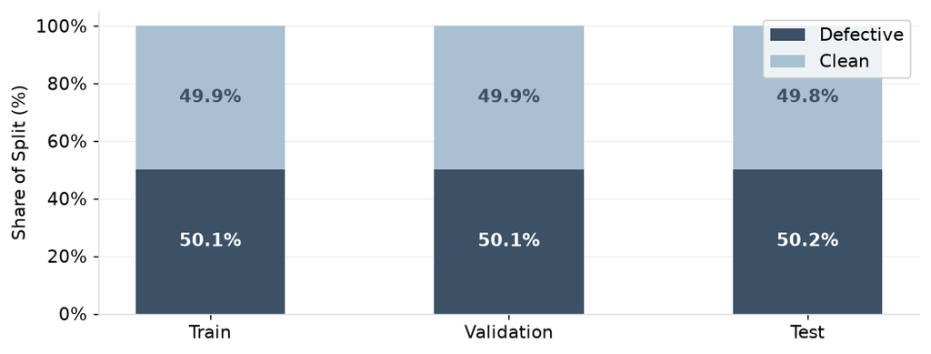

Section 3

## Model Selection

Three candidate classifiers were trained and evaluated on the validation set using Optuna hyperparameter optimization (150 trials per model). The best-performing model on validation ROC-AUC was selected and evaluated once on the held-out test set.

| Model | Val ROC-AUC | Val F1 | Val Precision | Val Recall |
| --- | --- | --- | --- | --- |
| Xgboost ✓ Selected | 0.7446 | 0.6573 | 0.6851 | 0.6317 |
| Logistic Regression | 0.7405 | 0.6568 | 0.6840 | 0.6317 |
| Random Forest | 0.7400 | 0.6486 | 0.6901 | 0.6119 |

Section 4

## Performance Metrics

Metrics for the selected model (Xgboost) are reported on both the validation set (used for model selection and hyperparameter tuning) and the test set (touched once, after model selection was complete). The test set is the honest estimate of real-world performance.

| Metric | Validation | Test (held-out) |
| --- | --- | --- |
| ROC-AUC | 0.7446 | 0.7625 |
| Avg Precision | 0.7705 | 0.7843 |
| F1 | 0.6573 | 0.6876 |
| Precision | 0.6851 | 0.7126 |
| Recall | 0.6317 | 0.6642 |

Section 4.1

## Learning Curve

Training vs Validation ROC-AUC by Training Set Size

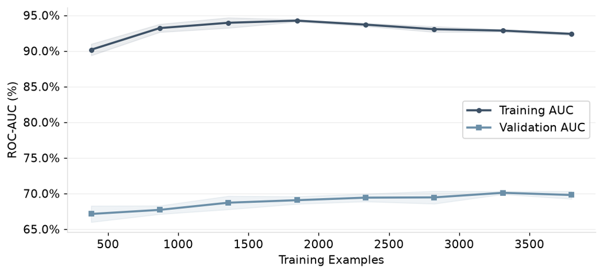

The ROC curve shows the tradeoff between true positive rate and false positive rate across all possible thresholds on the held-out test set.

ROC Curve — Test Set

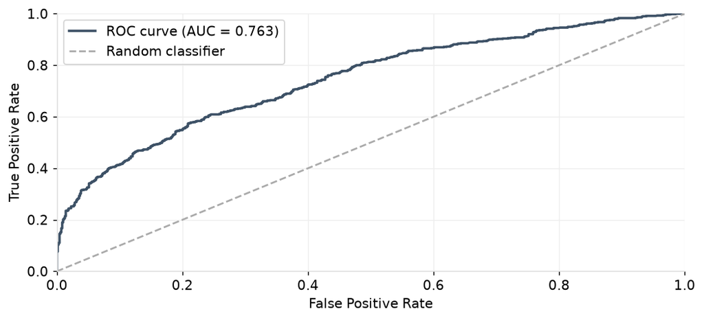

Section 4.2

## Calibration

A well-calibrated model tracks the diagonal — when it predicts 70% probability, approximately 70% of those jobs actually produce defects. Deviations from the diagonal indicate the raw probability outputs should be interpreted with caution.

Predicted Probability vs Actual Defect Rate

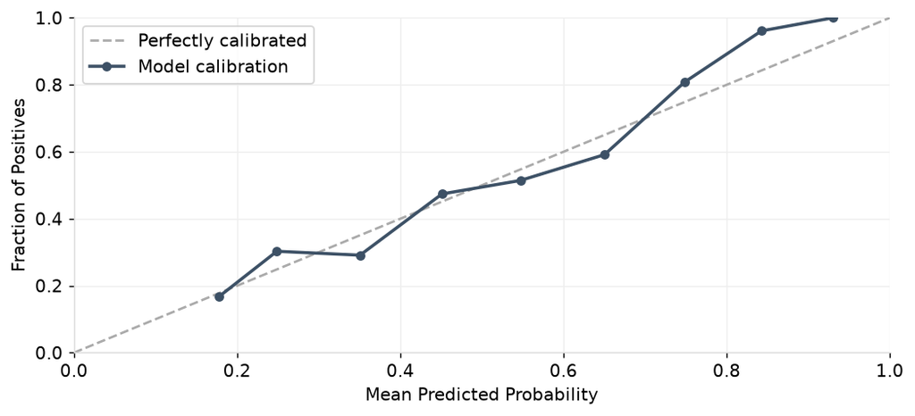

Section 4.3

## Precision-Recall Curve

Markers show the operating points for the High and Medium risk tiers. Moving left along the curve increases precision at the cost of recall.

Precision-Recall Curve with Operating Thresholds

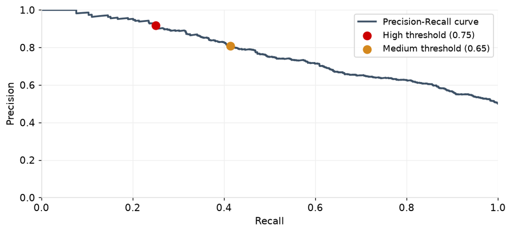

Section 4.4

## Confusion Matrix

True positives, false positives, true negatives, and false negatives at a 0.5 operating threshold on the held-out test set.

Confusion Matrix — Test Set

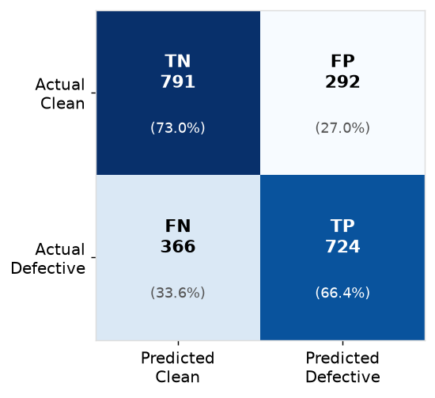

Section 5

## Feature Importance (SHAP)

SHAP (SHapley Additive exPlanations) values measure each feature's average contribution to the model's predictions across the validation set. Features with higher mean absolute SHAP values have greater influence on the model's output. SHAP values are computed on the validation set using TreeExplainer.

Features ranked by average impact on model output across the validation set. Interaction features appear prominently because they encode the strongest cross-system patterns identified in the diagnostic analysis.

Mean Absolute SHAP Value by Feature

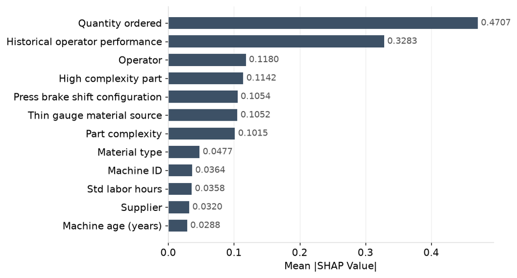

Section 6